# jekyll-jupyter-notebook20250203-2712-cfnuvw

### Question 2: Pricing of a Call Option

```python
import numpy as np
from scipy.stats import norm

def black_scholes_call(S, K, T, r, sigma):
  """
  Calculates the price of a European call option using the Black-Scholes formula.

  Args:
    S: Current stock price.
    K: Strike price.
    T: Time to expiration (in years).
    r: Risk-free interest rate.
    sigma: Implied volatility.

  Returns:
    The price of the European call option.
  """
  d1 = (np.log(S / K) + (r + 0.5 * sigma ** 2) * T) / (sigma * np.sqrt(T))
  d2 = d1 - sigma * np.sqrt(T)
  return S * norm.cdf(d1) - K * np.exp(-r * T) * norm.cdf(d2)
```

```python
# test call option price formula
S = 200
K = 180
T = 1/12
r = 0.02
sigma = 0.15

print("Price of call option = {}".format(black_scholes_call(S, K, T, r, sigma)))
```

```
Price of call option = 20.317700916589644
```

The Black-Scholes formula is used to calculate the theoretical price of a European call option. The formula is given by:

$$ C(S, t) = S_0 \cdot N(d_1) - K \cdot e^{-r(T - t)} \cdot N(d_2) $$

Where:

- $C(S, t)$ is the price of the call option.
- $S_0$ is the current stock price.
- $K$ is the strike price of the option.
- $T - t$ is the time to expiration of the option (in years).
- $r$ is the risk-free interest rate.
- $\sigma$ is the volatility of the stock's returns (standard deviation of returns).
- $N(\cdot)$ is the cumulative distribution function (CDF) of the standard normal distribution.
- $d_1$ and $d_2$ are calculated as follows:

$d_1 = \frac{\ln\left(\frac{S_0}{K}\right) + \left(r + \frac{\sigma^2}{2}\right)(T - t)}{\sigma \sqrt{T - t}}$

$d_2 = d_1 - \sigma \sqrt{T - t}$

### Question 3: Pricing call option using Monte Carlo

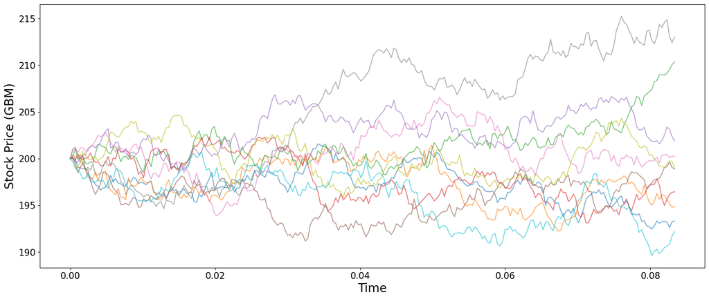

```python
def step(St, r, sigma, dt):
  # take one step of the geometric brownian motion
  return St * np.exp((r - 0.5 * sigma ** 2) * dt + sigma * np.sqrt(dt) * np.random.normal())
def get_path(S, r, sigma, tgrid):
  # get one path of geometric brownian motion and save all points
  St = S
  path = [St]
  for t in tgrid[1:]:
    St = step(St, r, sigma, tgrid[1]-tgrid[0])
    path.append(St)
  return np.array(path)
# generate a few example paths
S = 200
K = 180
T = 1/12
r = 0.02
sigma = 0.15
# discretize time
tgrid = np.linspace(0, T, 240)
plt.figure(4, figsize=(20, 8))
for i in range(10):
  # generate one path
  path = get_path(S, r, sigma, tgrid)
  plt.plot(tgrid, path, lw=1.5, alpha=0.6)
plt.xlabel('Time', fontsize=20)
plt.ylabel('Stock Price (GBM)', fontsize=20);
plt.xticks(fontsize=15)
plt.yticks(fontsize=15);
```

```python
def monte_carlo_price(S, K, tgrid, r, sigma, n):
  # approximate call option price using n paths of GBM
  all_prices = []
  for i in range(n):
    if i % 1000 == 0:
      print("simulating price = {}".format(i))
    # generate one path
    path = get_path(S, r, sigma, tgrid)
    # calculate call option price using simulated path
    option_price = np.maximum(path[-1] - K, 0)
    # save
    all_prices.append(option_price)
  return np.mean(all_prices)
```

```python
monte_carlo_price(S, K, tgrid, r, sigma, 100)
```

```
simulating price = 0
```

```
20.301260293551753
```

```
simulating price = 0
simulating price = 0
simulating price = 0
simulating price = 0
simulating price = 0
simulating price = 1000
simulating price = 2000
simulating price = 3000
simulating price = 4000
simulating price = 0
simulating price = 1000
simulating price = 2000
simulating price = 3000
simulating price = 4000
simulating price = 5000
simulating price = 6000
simulating price = 7000
simulating price = 8000
simulating price = 9000
```

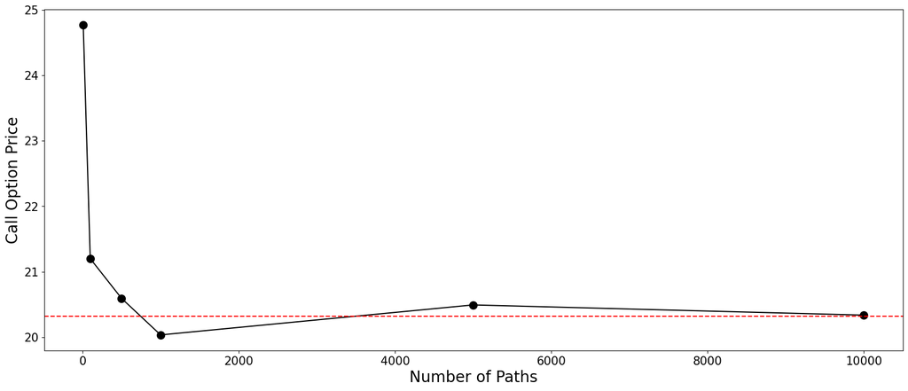

```python
# fix seed
np.random.seed(123)
# test a range of n
n = np.array([10, 100, 500, 1000, 5000, 10000])
all_prices = []
for i in range(len(n)):
  all_prices.append(monte_carlo_price(S, K, tgrid, r, sigma, n[i]))

# plot convergence
plt.figure(5, figsize=(20, 8))
plt.plot(n, all_prices, "-o", markersize=10, color="black", lw=1.5);
plt.axhline(y=black_scholes_call(S, K, T, r, sigma), color='r', linestyle='--')
plt.xlabel('Number of Paths', fontsize=20)
plt.ylabel('Call Option Price', fontsize=20);
plt.xticks(fontsize=15)
plt.yticks(fontsize=15);
```